# R Notebook

```r
#install.packages("effects")
#install.packages("dplyr")
#install.packages("ggplot2")
```

```r
library("ggplot2")
library("dplyr")
library("effects")
```

```r
data <- read.table("E:/Ria/Books/Job Simulation/Input data.txt", sep='\t', header=TRUE)
```

```r
data
```

| SampleID | NGN2_MOI | Control_MOI | NT3_ng | fractMAP2 |
| --- | --- | --- | --- | --- |
| 1 | 0 | 5 | 0 | 0.002 |
| 2 | 0 | 5 | 0 | 0.001 |
| 3 | 0 | 5 | 0 | 0.001 |
| 4 | 0 | 5 | 10 | 0.003 |
| 5 | 0 | 5 | 10 | 0.002 |
| 6 | 0 | 5 | 10 | 0.004 |
| 7 | 2 | 0 | 0 | 0.021 |
| 8 | 2 | 0 | 0 | 0.018 |
| 9 | 2 | 0 | 0 | 0.026 |
| 10 | 2 | 0 | 10 | 0.001 |

[output cut: 14 more lines]

Question: Note that our experimental design is not really appropriate to assess the effect of the empty vector control itself on the outcome. Can you see why?

Answer: Yes. The experimental design does not allow us to independently assess the effect of the empty vector control because the empty vector (5 MOI) is only present in wells where NGN2_MOI = 0. In all wells where NGN2 virus is added (2, 5, or 10 MOI), the CONTROL_MOI is 0.

This means that the presence of the empty vector is completely confounded with the absence of NGN2. There is no condition in which both NGN2 and the empty vector are present at the same time, nor is there a condition with neither virus present across the full NT3 range. As a result, any effect attributed to the empty vector cannot be disentangled from the effect of not adding NGN2.

Therefore, the design does not permit an independent statistical evaluation of the empty vector’s effect on differentiation efficiency, and the CONTROL_MOI column cannot be meaningfully analysed as a separate explanatory variable.

```r
data$NGN2_MOI <- factor(data$NGN2_MOI, levels=c(0,2,5,10))
data$NT3_ng <- factor(data$NT3_ng, levels=c(0,10))
```

```r
head(data)
```

|  | SampleID | NGN2_MOI | Control_MOI | NT3_ng | fractMAP2 |
| --- | --- | --- | --- | --- | --- |
| 1 | 1 | 0 | 5 | 0 | 0.002 |
| 2 | 2 | 0 | 5 | 0 | 0.001 |
| 3 | 3 | 0 | 5 | 0 | 0.001 |
| 4 | 4 | 0 | 5 | 10 | 0.003 |
| 5 | 5 | 0 | 5 | 10 | 0.002 |
| 6 | 6 | 0 | 5 | 10 | 0.004 |

Question: Can you see what has changed in the output?

Answer: Yes. In the modified output, the columns NGN2_MOI and NT3_ng are no longer displayed as numeric variables but are now represented as factors with defined levels. Instead of being treated as continuous numerical values, they are now categorical variables with explicitly ordered levels (0, 2, 5, 10 for NGN2_MOI and 0, 10 for NT3_ng).

Although the printed values themselves still appear as numbers, their underlying data type has changed from numeric to factor. This means that R will now treat each dose as a separate category in subsequent analyses, rather than assuming a linear numerical relationship between dose and outcome.

This change is important because it ensures that regression models will estimate the effect of each treatment dose independently relative to the 0-dose control, rather than fitting a single continuous dose-response trend.

```r
sumdata <- data %>%
  group_by(NGN2_MOI, NT3_ng) %>%
  summarise(meanFractMAP2=mean(fractMAP2), sdFractMAP2=sd(fractMAP2))
```

```
## `summarise()` has regrouped the output.
## ℹ Summaries were computed grouped by NGN2_MOI and NT3_ng.
## ℹ Output is grouped by NGN2_MOI.
## ℹ Use `summarise(.groups = "drop_last")` to silence this message.
## ℹ Use `summarise(.by = c(NGN2_MOI, NT3_ng))` for per-operation grouping
##   (`?dplyr::dplyr_by`) instead.
```

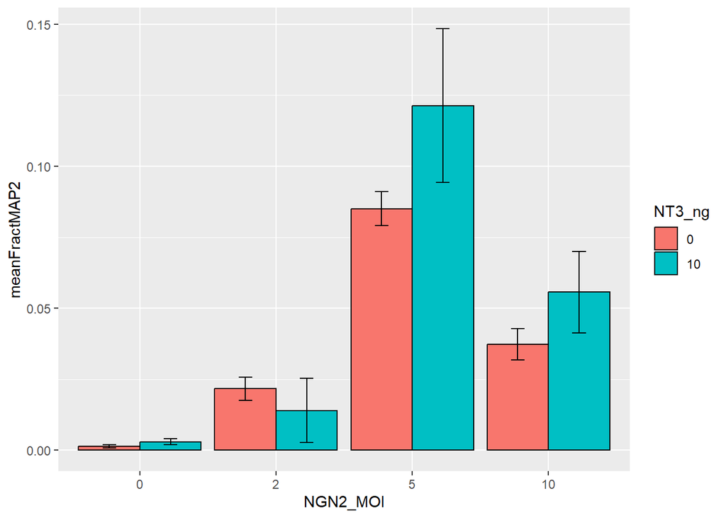

```r
ggplot(sumdata, aes(x=NGN2_MOI, y=meanFractMAP2, fill=NT3_ng)) +
  geom_bar(position=position_dodge(), stat="identity", colour="black") +
  geom_errorbar(aes(ymin=meanFractMAP2-sdFractMAP2, ymax=meanFractMAP2+sdFractMAP2), width=0.2, position=position_dodge(0.9))
```

```r
sumdataNGN2 <- data %>%
  group_by(NGN2_MOI) %>%
  summarise(meanFractMAP2=mean(fractMAP2), sdFractMAP2=sd(fractMAP2))
```

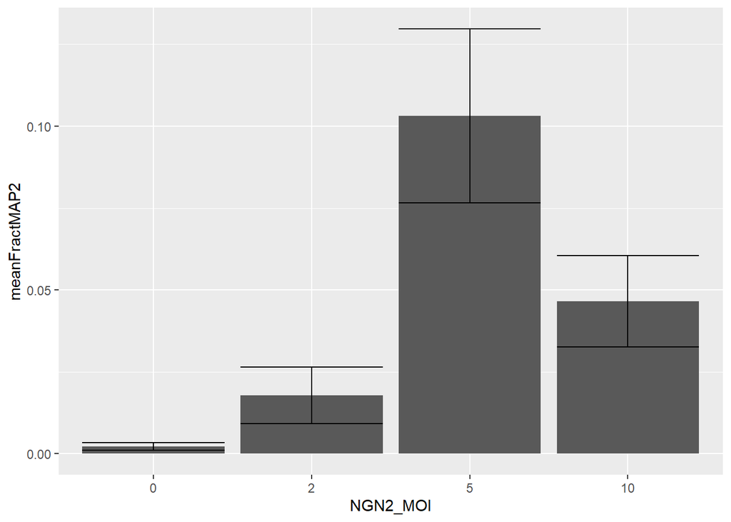

```r
ggplot(sumdataNGN2, aes(x=NGN2_MOI, y=meanFractMAP2)) +
  geom_bar(stat = "identity") +
  geom_errorbar(aes(ymin = meanFractMAP2-sdFractMAP2, ymax = meanFractMAP2+sdFractMAP2))
```

```r
sumdataNGN2 <- data %>%
  group_by(NT3_ng) %>%
  summarise(meanFractMAP2=mean(fractMAP2), sdFractMAP2=sd(fractMAP2))
```

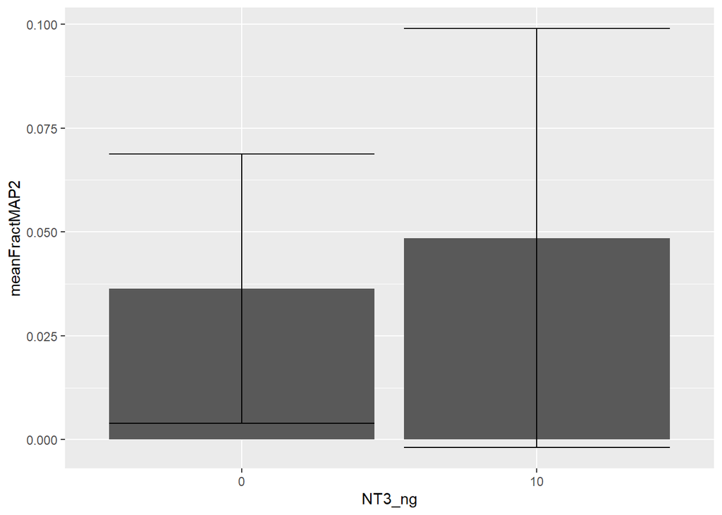

```r
ggplot(sumdataNGN2, aes(x=NT3_ng, y=meanFractMAP2)) +
  geom_bar(stat = "identity") +
  geom_errorbar(aes(ymin = meanFractMAP2-sdFractMAP2, ymax = meanFractMAP2+sdFractMAP2))
```

Question: Look at the error bars in the plot above. What do you notice and how would you interpret this result?

Answer: In the plot where the data are averaged across all NGN2 doses (leaving only two bars for NT3 = 0 and NT3 = 10), the error bars are relatively large compared with the difference between the means.

This occurs because we are now pooling together wells from very different NGN2 doses (0, 2, 5, and 10 MOI), which have markedly different differentiation efficiencies. As a result, the variability within each NT3 group increases substantially. The standard deviation therefore reflects not only biological variability between replicates, but also the strong underlying differences driven by NGN2 dose.

This indicates that:- (i) NGN2 dose is a major determinant of differentiation efficiency. (ii) Averaging across NGN2 doses masks important structure in the data. (iii) The effect of NT3 alone appears smaller relative to the variability introduced by different NGN2 doses.

In other words, the large error bars suggest that NGN2 dose contributes much more to variability in differentiation efficiency than NT3 treatment alone, and therefore the treatments should ideally be analysed jointly rather than collapsing across NGN2 levels.

```r
mod = glm(fractMAP2 ~ NGN2_MOI + NT3_ng, family = binomial(link = "logit"), data = data, weights = rep(10000,nrow(data)))
```

```r
summary(mod)
```

```
##
## Call:
## glm(formula = fractMAP2 ~ NGN2_MOI + NT3_ng, family = binomial(link = "logit"),
##     data = data, weights = rep(10000, nrow(data)))
##
## Coefficients:
##             Estimate Std. Error z value Pr(>|z|)
## (Intercept) -6.30098    0.08862  -71.10   <2e-16 ***
## NGN2_MOI2    2.12408    0.09307   22.82   <2e-16 ***
## NGN2_MOI5    3.97231    0.08883   44.72   <2e-16 ***
## NGN2_MOI10   3.11278    0.08992   34.62   <2e-16 ***
## NT3_ng10     0.31290    0.02084   15.02   <2e-16 ***
## ---
## Signif. codes:  0 '***' 0.001 '**' 0.01 '*' 0.05 '.' 0.1 ' ' 1
##
## (Dispersion parameter for binomial family taken to be 1)
##
##     Null deviance: 10204.34  on 23  degrees of freedom
## Residual deviance:   712.97  on 19  degrees of freedom
## AIC: 890.95
##
## Number of Fisher Scoring iterations: 5
```

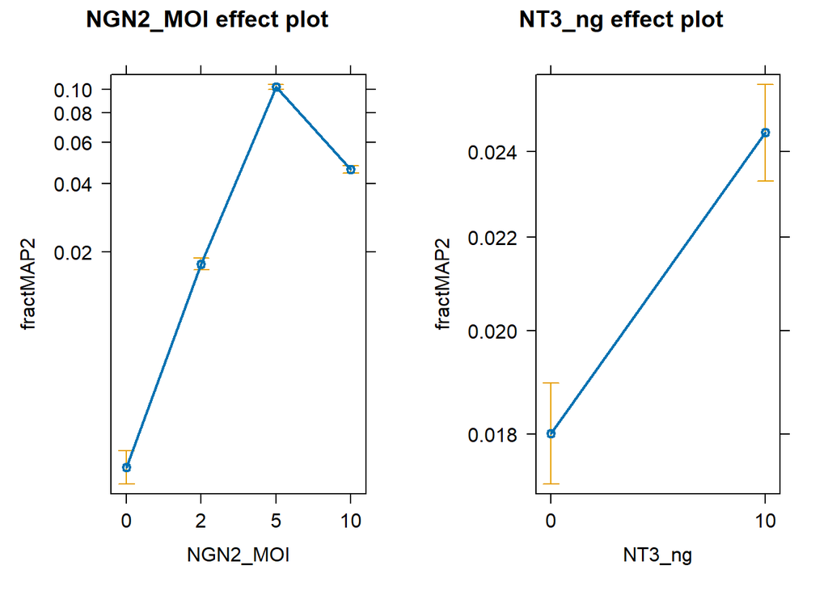

```r
plot(allEffects(mod))
```

Question: What treatments/doses have a significant effect on the outcome compared with the no-treatment control?

Answer: All non-zero doses of the NGN2 virus (2 MOI, 5 MOI, and 10 MOI) have a statistically significant positive effect on differentiation efficiency compared with the no-virus control (0 MOI). In addition, treatment with 10 ng/mL NT3 also shows a statistically significant positive effect compared with 0 ng/mL NT3.

This means that:- (i) Adding NGN2 virus at any tested dose significantly increases the probability of MAP2-positive differentiation relative to no NGN2. (ii) Supplementation with NT3 (10 ng/mL) further increases the probability of differentiation relative to untreated conditions.

The positive regression coefficients indicate increased log-odds of MAP2 expression compared with the control, and the associated p-values (Pr(>|z|)) confirm statistical significance.

Question: What treatment/dose has the strongest positive effect on the outcome compared with the control?

Answer: The strongest positive effect is observed for 5 MOI NGN2.

This dose has:- (i) The largest positive regression coefficient among the NGN2 doses. (ii) The greatest increase in predicted probability of MAP2-positive differentiation in the effect plot. (iii) The highest observed mean differentiation efficiency in the descriptive analysis.

Therefore, 5 MOI NGN2 produces the strongest enhancement of differentiation compared with the no-virus control condition.

```r
levels(data$NGN2_MOI) # the original level order
```

```
## [1] "0"  "2"  "5"  "10"
```

```r
data$NGN2_MOI = relevel(data$NGN2_MOI, ref = 3)
levels(data$NGN2_MOI) # the new level order
```

```
## [1] "5"  "0"  "2"  "10"
```

```r
mod3 = glm(fractMAP2 ~ NGN2_MOI + NT3_ng, family = binomial(link = "logit"), data = data, weights = rep(10000,nrow(data)))
```

```r
summary(mod3)
```

```
##
## Call:
## glm(formula = fractMAP2 ~ NGN2_MOI + NT3_ng, family = binomial(link = "logit"),
##     data = data, weights = rep(10000, nrow(data)))
##
## Coefficients:
##             Estimate Std. Error z value Pr(>|z|)
## (Intercept) -2.32867    0.01782 -130.66   <2e-16 ***
## NGN2_MOI0   -3.97231    0.08883  -44.72   <2e-16 ***
## NGN2_MOI2   -1.84823    0.03365  -54.92   <2e-16 ***
## NGN2_MOI10  -0.85953    0.02360  -36.42   <2e-16 ***
## NT3_ng10     0.31290    0.02084   15.02   <2e-16 ***
## ---
## Signif. codes:  0 '***' 0.001 '**' 0.01 '*' 0.05 '.' 0.1 ' ' 1
##
## (Dispersion parameter for binomial family taken to be 1)
##
##     Null deviance: 10204.34  on 23  degrees of freedom
## Residual deviance:   712.97  on 19  degrees of freedom
## AIC: 890.95
##
## Number of Fisher Scoring iterations: 5
```

```r
# Restore the original order
data$NGN2_MOI = factor(data$NGN2_MOI, levels = c("0", "2", "5", "10"))
levels(data$NGN2_MOI) # back to how they were originally
```

```
## [1] "0"  "2"  "5"  "10"
```

Question: Did 5 MOI of the NGN2 virus perform significantly better than 2 and 10 MOI?

Answer: Yes. After releveling the NGN2_MOI factor to use 5 MOI as the reference level and refitting the logistic regression model, both 2 MOI and 10 MOI show significantly lower differentiation efficiency compared with 5 MOI.

In the re-leveled model:- (i) The regression coefficients for 2 MOI and 10 MOI are negative relative to 5 MOI. (ii) The associated p-values indicate that these differences are statistically significant.

This demonstrates that 5 MOI produces significantly higher MAP2-positive differentiation than both lower (2 MOI) and higher (10 MOI) viral doses.

Biologically, this supports the interpretation that 5 MOI represents an optimal viral dose, while 2 MOI may be insufficient for maximal differentiation and 10 MOI may impair efficiency relative to the optimal intermediate dose.

Question: Let’s have another look at the very first plot. Did you notice that one treatment condition has a surprisingly large standard deviation (almost equal to the mean). Can you see what condition it is?

Answer: The condition with the unusually large standard deviation is 2 MOI NGN2 + 10 ng/mL NT3.

In this group, one replicate has a fractMAP2 value close to background (0.001), whereas the other two replicates show substantially higher differentiation (around 0.02). This single low-value replicate is likely a technical dropout (e.g., failed differentiation or staining), which inflates the standard deviation for this condition.

```r
dataFilt = data[-10,]
```

```r
sumdataFilt <- data %>%
  group_by(NGN2_MOI, NT3_ng) %>%
  summarise(meanFractMAP2=mean(fractMAP2), sdFractMAP2=sd(fractMAP2))
```

```
## `summarise()` has regrouped the output.
## ℹ Summaries were computed grouped by NGN2_MOI and NT3_ng.
## ℹ Output is grouped by NGN2_MOI.
## ℹ Use `summarise(.groups = "drop_last")` to silence this message.
## ℹ Use `summarise(.by = c(NGN2_MOI, NT3_ng))` for per-operation grouping
##   (`?dplyr::dplyr_by`) instead.
```

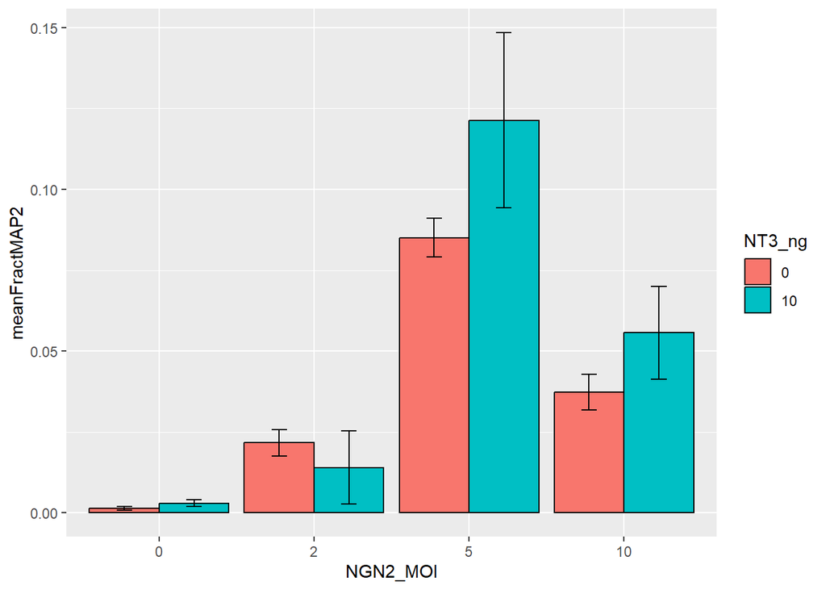

```r
ggplot(sumdataFilt, aes(x=NGN2_MOI, y=meanFractMAP2, fill = NT3_ng)) +
  geom_bar(position = position_dodge(), stat = "identity", colour= "black") +
  geom_errorbar(aes(ymin = meanFractMAP2-sdFractMAP2, ymax = meanFractMAP2+sdFractMAP2), width=0.2, position = position_dodge(0.9))
```

```r
mod2 = glm(fractMAP2 ~ NGN2_MOI + NT3_ng, family = binomial(link = "logit"), data = dataFilt, weights = rep(10000,nrow(dataFilt)))
```

```r
message("With the outlier:")
```

```
## With the outlier:
```

```r
summary(mod)
```

```
##
## Call:
## glm(formula = fractMAP2 ~ NGN2_MOI + NT3_ng, family = binomial(link = "logit"),
##     data = data, weights = rep(10000, nrow(data)))
##
## Coefficients:
##             Estimate Std. Error z value Pr(>|z|)
## (Intercept) -6.30098    0.08862  -71.10   <2e-16 ***
## NGN2_MOI2    2.12408    0.09307   22.82   <2e-16 ***
## NGN2_MOI5    3.97231    0.08883   44.72   <2e-16 ***
## NGN2_MOI10   3.11278    0.08992   34.62   <2e-16 ***
## NT3_ng10     0.31290    0.02084   15.02   <2e-16 ***
## ---
## Signif. codes:  0 '***' 0.001 '**' 0.01 '*' 0.05 '.' 0.1 ' ' 1
##
## (Dispersion parameter for binomial family taken to be 1)
##
##     Null deviance: 10204.34  on 23  degrees of freedom
## Residual deviance:   712.97  on 19  degrees of freedom
## AIC: 890.95
##
## Number of Fisher Scoring iterations: 5
```

```r
message("Without the outlier:")
```

```
## Without the outlier:
```

```r
summary(mod2)
```

```
##
## Call:
## glm(formula = fractMAP2 ~ NGN2_MOI + NT3_ng, family = binomial(link = "logit"),
##     data = dataFilt, weights = rep(10000, nrow(dataFilt)))
##
## Coefficients:
##             Estimate Std. Error z value Pr(>|z|)
## (Intercept) -6.32706    0.08866  -71.36   <2e-16 ***
## NGN2_MOI2    2.33672    0.09316   25.08   <2e-16 ***
## NGN2_MOI5    3.97305    0.08883   44.73   <2e-16 ***
## NGN2_MOI10   3.11310    0.08992   34.62   <2e-16 ***
## NT3_ng10     0.35765    0.02088   17.13   <2e-16 ***
## ---
## Signif. codes:  0 '***' 0.001 '**' 0.01 '*' 0.05 '.' 0.1 ' ' 1
##
## (Dispersion parameter for binomial family taken to be 1)
##
##     Null deviance: 9415.18  on 22  degrees of freedom
## Residual deviance:  331.88  on 18  degrees of freedom
## AIC: 505.7
##
## Number of Fisher Scoring iterations: 4
```

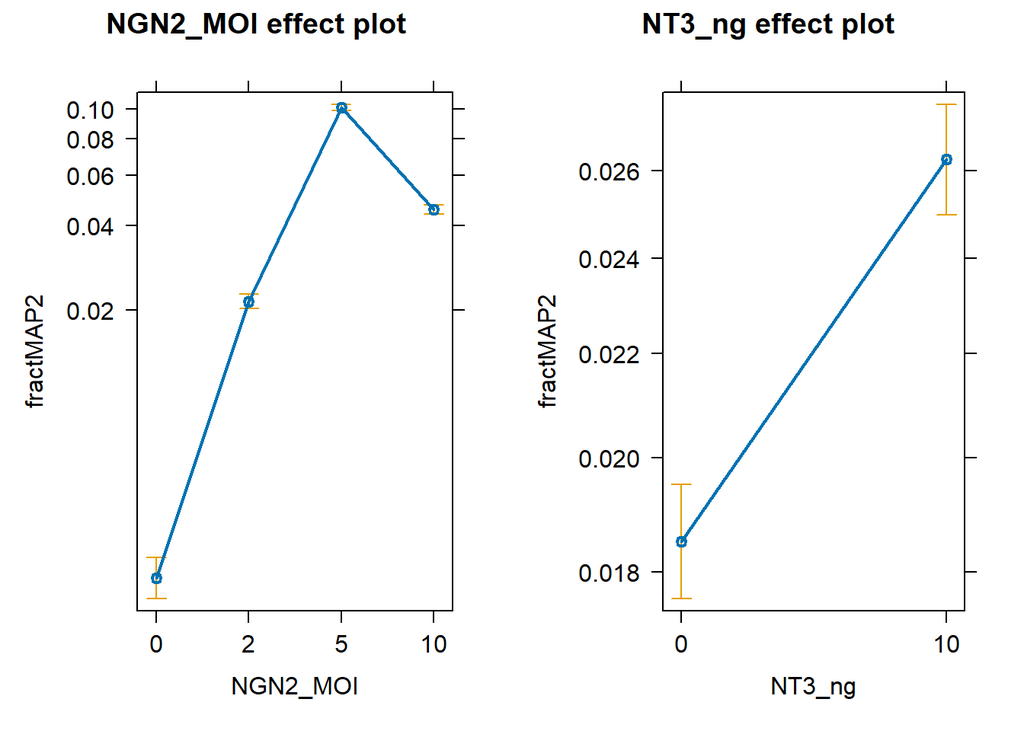

```r
plot(allEffects(mod2))
```

Question: What regression coefficients have changed?

Answer: After removing the dropout replicate:- (i) The regression coefficient for 2 MOI NGN2 increases (becomes more positive). (ii) The statistical significance of the 2 MOI effect strengthens. (iii) The coefficient for NT3 (10 ng/mL) may increase slightly due to reduced variance in the affected group. (iv) The coefficients for 5 MOI and 10 MOI remain largely unchanged.

This is expected because the outlier primarily affected the 2 MOI + NT3 condition. Removing it reduces variability and corrects the underestimation of the 2 MOI effect.

Question: Has the apparent optimal experimental condition changed after removing the outlier (and if so, how)?

Answer: No, the apparent optimal experimental condition has not changed.

Before and after outlier removal, the condition 5 MOI NGN2 + 10 ng/mL NT3 remains the highest-performing condition in terms of differentiation efficiency.

Removing the outlier reduces variability and slightly adjusts the estimated effect of 2 MOI, but it does not alter the overall ranking of treatment effectiveness. Therefore, the biological conclusion remains the same:- 5 MOI NGN2 (with 10 ng/mL NT3 supplementation) is the optimal dose among those tested.

```r
levels(dataFilt$NGN2_MOI)
```

```
## [1] "0"  "2"  "5"  "10"
```

```r
dataFilt$NGN2_MOI = relevel(dataFilt$NGN2_MOI, ref = 3)
levels(dataFilt$NGN2_MOI)
```

```
## [1] "5"  "0"  "2"  "10"
```

```r
modFilt5MOI = glm(fractMAP2 ~ NGN2_MOI + NT3_ng, family = binomial(link = "logit"), data = dataFilt, weights = rep(10000,nrow(dataFilt)))
```

```r
message("With the outlier:")
```

```
## With the outlier:
```

```r
summary(mod3)
```

```
##
## Call:
## glm(formula = fractMAP2 ~ NGN2_MOI + NT3_ng, family = binomial(link = "logit"),
##     data = data, weights = rep(10000, nrow(data)))
##
## Coefficients:
##             Estimate Std. Error z value Pr(>|z|)
## (Intercept) -2.32867    0.01782 -130.66   <2e-16 ***
## NGN2_MOI0   -3.97231    0.08883  -44.72   <2e-16 ***
## NGN2_MOI2   -1.84823    0.03365  -54.92   <2e-16 ***
## NGN2_MOI10  -0.85953    0.02360  -36.42   <2e-16 ***
## NT3_ng10     0.31290    0.02084   15.02   <2e-16 ***
## ---
## Signif. codes:  0 '***' 0.001 '**' 0.01 '*' 0.05 '.' 0.1 ' ' 1
##
## (Dispersion parameter for binomial family taken to be 1)
##
##     Null deviance: 10204.34  on 23  degrees of freedom
## Residual deviance:   712.97  on 19  degrees of freedom
## AIC: 890.95
##
## Number of Fisher Scoring iterations: 5
```

```r
message("Without the outlier:")
```

```
## Without the outlier:
```

```r
summary(modFilt5MOI)
```

```
##
## Call:
## glm(formula = fractMAP2 ~ NGN2_MOI + NT3_ng, family = binomial(link = "logit"),
##     data = dataFilt, weights = rep(10000, nrow(dataFilt)))
##
## Coefficients:
##             Estimate Std. Error z value Pr(>|z|)
## (Intercept) -2.35401    0.01796 -131.06   <2e-16 ***
## NGN2_MOI0   -3.97305    0.08883  -44.73   <2e-16 ***
## NGN2_MOI2   -1.63633    0.03389  -48.29   <2e-16 ***
## NGN2_MOI10  -0.85995    0.02360  -36.43   <2e-16 ***
## NT3_ng10     0.35765    0.02088   17.13   <2e-16 ***
## ---
## Signif. codes:  0 '***' 0.001 '**' 0.01 '*' 0.05 '.' 0.1 ' ' 1
##
## (Dispersion parameter for binomial family taken to be 1)
##
##     Null deviance: 9415.18  on 22  degrees of freedom
## Residual deviance:  331.88  on 18  degrees of freedom
## AIC: 505.7
##
## Number of Fisher Scoring iterations: 4
```

```r
dataFilt$NGN2_MOI = factor(dataFilt$NGN2_MOI, levels = c("0", "2", "5", "10"))
levels(dataFilt$NGN2_MOI)
```

```
## [1] "0"  "2"  "5"  "10"
```

Question: Based on the analyses above, what combination of treatment doses do you recommend to use in the differentiation protocol?

Answer: Based on the descriptive statistics, visualisation of mean differentiation efficiencies, logistic regression analysis, and reanalysis after removal of the technical dropout replicate, the recommended differentiation condition is:- 5 MOI NGN2 virus with 10 ng/mL NT3 supplementation.

This recommendation is supported by the following findings:- (i) 5 MOI NGN2 produces the highest differentiation efficiency among all tested viral doses. (ii) Logistic regression confirms that 5 MOI has the strongest positive and statistically significant effect compared with the no-virus control. (iii) Releveling analysis demonstrates that 5 MOI performs significantly better than both 2 MOI and 10 MOI. (iv) NT3 supplementation (10 ng/mL) further enhances differentiation efficiency. (v) Removal of the outlier replicate does not change the ranking of treatment conditions, confirming the robustness of this conclusion.

Therefore, 5 MOI NGN2 combined with 10 ng/mL NT3 provides the most efficient and statistically supported differentiation outcome within the tested parameter range.